# STAT-670-Assignment 6

March 25, 2019

**Team Members (Mini-Project2 : Team Colorado)**:  
Prashanth Thirukkurungudi Sekar, Pravin Sundar,  
Barathwaaj Parthasarathy, Bhavna Sinha

```r
library(ggplot2)
library(tidyverse)
library(MASS)
library(mgcv)
```

```r
minnesota.barley.yield <- read.csv("minnesota.barley.yield.txt", sep="")
```

### Cleaning the data

```r
data_1 = droplevels(subset(minnesota.barley.yield,!is.element(gen,c("CompCross","Dryland","Jeans","MechMixture","Heinrichs","Minsturdi","Spartan","No475","Colsess","No474","WisNo38"))))
data_2 = droplevels(subset(data_1,!is.element(year,c(1933,1934,1935,1936))))
```

There is no data for Morris during 1933 and 1934 and since we are looking at trends in yield at different locations for successive years, we considered data upto 1932. Also, varieties which are not present for all the years (or) for all the locations were dropped from the data to ensure that the plots are interprettable since they are colored based on the varieties.

## Question 1

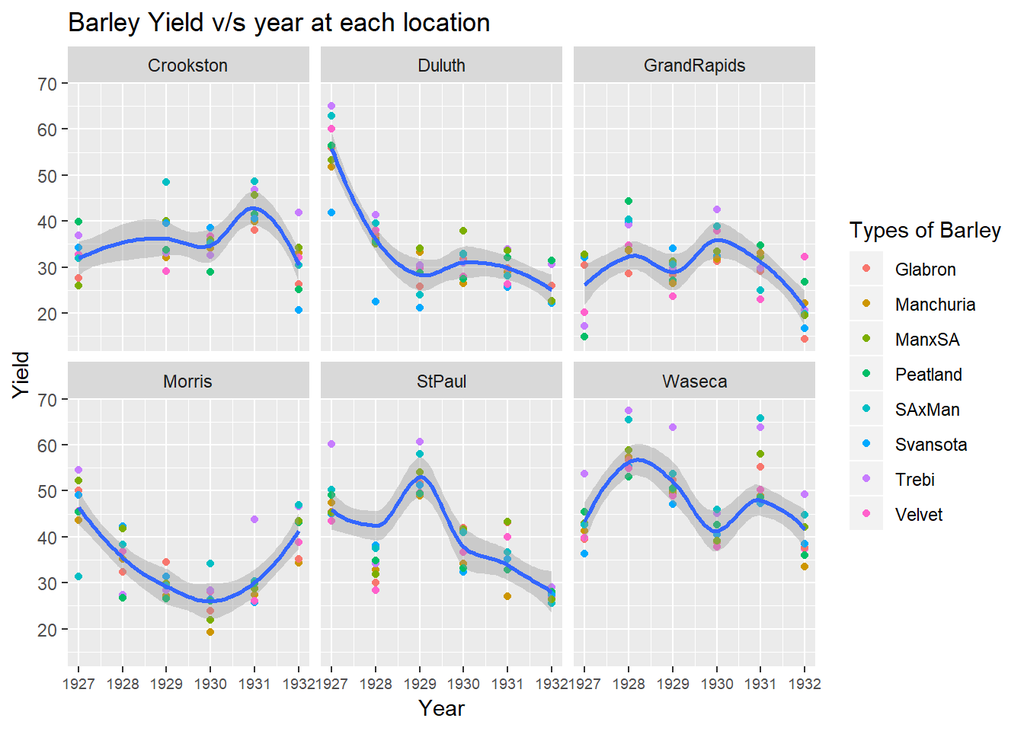

```r
ggplot(data_2,aes(x=year,y=yield)) +geom_point(aes(color = factor(gen))) + geom_smooth(method="loess") + facet_wrap(~site) +  ggtitle("Barley Yield v/s year at each location") + labs(x="Year",y="Yield") +  labs(color='Types of Barley')+ theme(axis.text.x =
                   element_text(size  = 7)) #+ scale_x_discrete(limits=c(1928,1930,1932,1934,1936))
```

Note: The same trend can be observed through the graph present in the appendix (Point 1) where individual lines indicate the yield for each variety of barley.

## Question 2

```r
#data_2 = minnesota.barley.yield
yield.rlm = rlm(yield ~ gen+factor(year)+site,data= data_2,psi = psi.bisquare)
summary(yield.rlm)
```

```
##
## Call: rlm(formula = yield ~ gen + factor(year) + site, data = data_2,
##     psi = psi.bisquare)
## Residuals:
##      Min       1Q   Median       3Q      Max
## -21.3026  -5.2572  -0.4831   5.1109  24.4522
##
## Coefficients:
##                  Value    Std. Error t value
## (Intercept)       39.5053   2.1365    18.4909
## genManchuria      -0.9250   1.9948    -0.4637
## genManxSA          2.3189   1.9797     1.1713
## genPeatland        0.2295   1.9797     0.1159
## genSAxMan          2.6294   1.9948     1.3181
## genSvansota       -0.8602   1.9941    -0.4313
## genTrebi           4.8150   1.9797     2.4321
## genVelvet         -0.6600   1.9797    -0.3334
## factor(year)1928  -1.0853   1.7953    -0.6045
## factor(year)1929  -3.5624   1.6970    -2.0992
## factor(year)1930  -6.7086   1.6970    -3.9531
## factor(year)1931  -3.9188   1.6970    -2.3092
## factor(year)1932 -10.9942   1.7162    -6.4059
## siteDuluth        -3.2974   1.7757    -1.8570
## siteGrandRapids   -5.8177   1.7953    -3.2405
## siteMorris        -2.3016   1.7851    -1.2893
## siteStPaul         3.1449   1.7851     1.7617
## siteWaseca        12.1341   1.7757     6.8336
##
## Residual standard error: 7.763 on 258 degrees of freedom
```

Given the nature of the data with few outliers, we decided to proceed with a robust linear model in order to down weight outliers. The response variable is Yield and gen (Variety), year (as a factor) and site as explanatory variables. We also tried fitting a Generalized Additive Models (GAM) with the same set of explanatory variables and observed that the results were very similar to the robust linear model. Hence, we decided to proceed with the RLM model.

## Question 3

```r
yield.rlm.df = data.frame(data_2, .fitted = fitted.values(yield.rlm), .resid = residuals(yield.rlm))
```

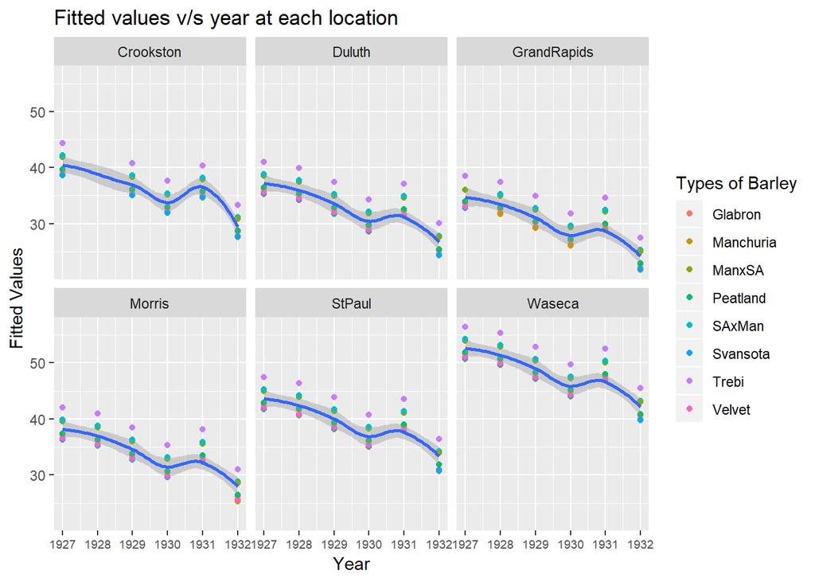

```r
ggplot(yield.rlm.df, aes(x=(year),y=.fitted)) + geom_point(aes(color=factor(gen))) + geom_smooth() + facet_wrap(~site) +  ggtitle("Fitted values v/s year at each location") + labs(x="Year",y="Fitted Values") +  labs(color='Types of Barley') + theme(axis.text.x =
                   element_text(size  = 7))
```

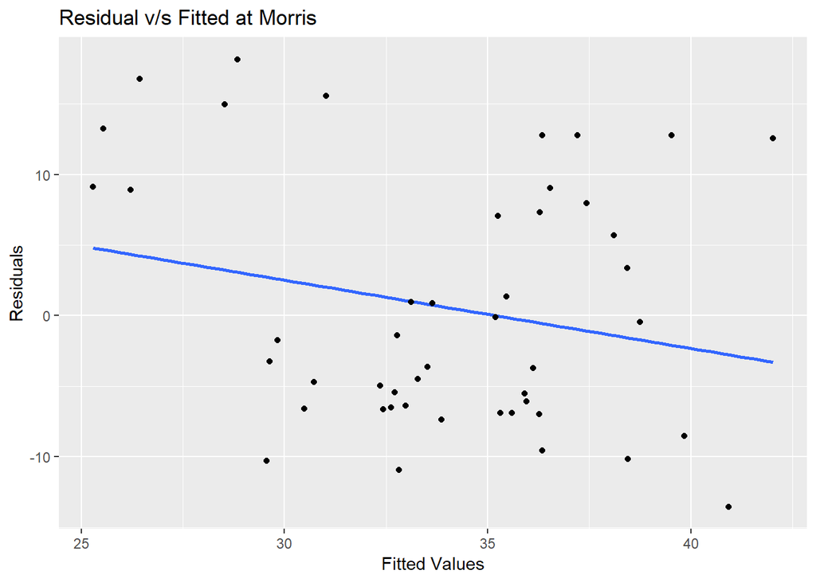

```r
ggplot(yield.rlm.df[yield.rlm.df$site=="Morris",],aes(x=.fitted,y=(.resid))) + geom_smooth(method="gam",se=F) +geom_point() + ggtitle("Residual v/s Fitted at Morris") + labs(x="Fitted Values",y="Residuals")
```

From the first plot(fitted values v/s year), we can see that the trend of yield by year is very similar across all locations with only shifts in the yield values. From this, we can see that there is no conlusive evidence on whether Morris 1931-1932 is a mistake. Because, if there was an anomally in the data then we could expect a variation in the trend for Morris when compared to the other locations in the fitted graph.

Note: A similar trend can be observed through the line plot mentioned in point 3 of appendix.

We also tried fitting a RLM model after swapping the data for years 1931 and 1932 for Morris and the residual plots of the swapped model did not indicate any abnormality in the data.

## Appendix

#### Point 1

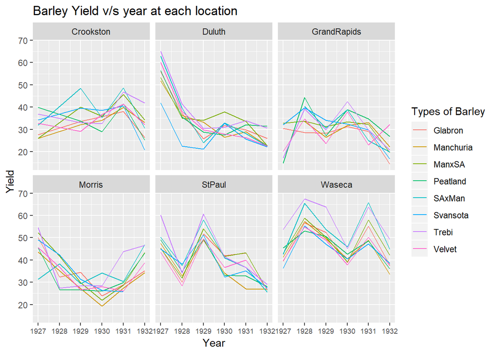

```r
ggplot(data_2,aes(x=year,y=yield,color=factor(gen))) +geom_line()  +facet_wrap(~site) +  ggtitle("Barley Yield v/s year at each location") + labs(x="Year",y="Yield") +  labs(color='Types of Barley') + theme(axis.text.x =
                   element_text(size  = 7))
```

#### Point 2

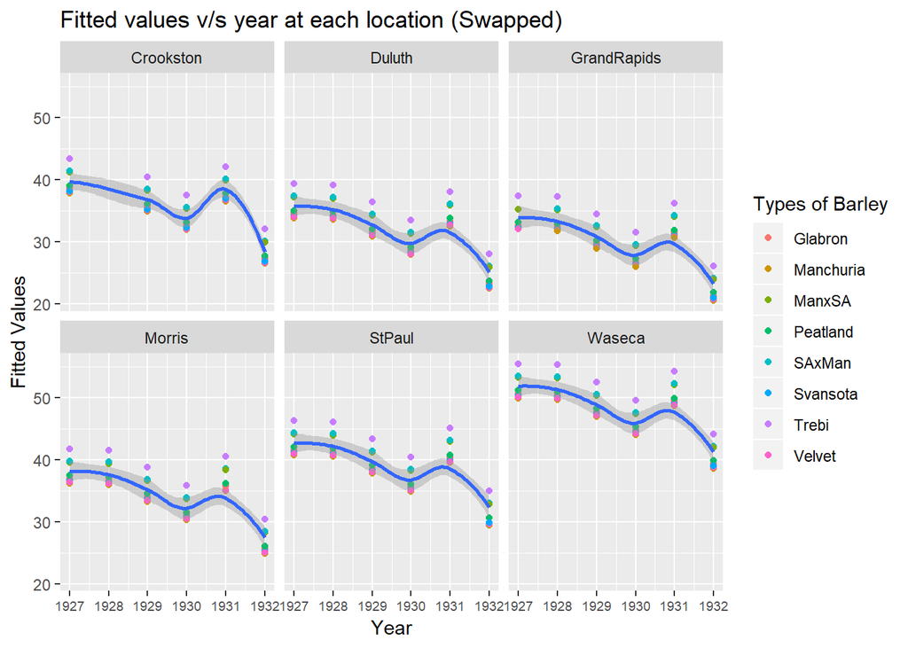

```r
d0  <- read.csv("minnesota.barley.yield.txt", sep="")
d0$year = ifelse(d0$year==1931 & d0$site=="Morris",2000,d0$year)
d0$year = ifelse(d0$year==1932 & d0$site=="Morris",1931,d0$year)
d0$year = ifelse(d0$year==2000 & d0$site=="Morris",1932,d0$year)

data_1_v1 = droplevels(subset(d0,!is.element(gen,c("CompCross","Dryland","Jeans","MechMixture","Heinrichs","Minsturdi","Spartan","No475","Colsess","No474","WisNo38"))))
data_2_v1 = droplevels(subset(data_1_v1,!is.element(year,c(1933,1934,1935,1936))))

yield.rlm1 = rlm(yield ~ gen+factor(year)+site,data= data_2_v1,psi = psi.bisquare)
yield.rlm1.df = data.frame(data_2_v1, .fitted = fitted.values(yield.rlm1), .resid = residuals(yield.rlm1))

ggplot(yield.rlm1.df, aes(x=(year),y=.fitted)) + geom_point(aes(color=factor(gen))) + geom_smooth() + facet_wrap(~site) +  ggtitle("Fitted values v/s year at each location (Swapped)") + labs(x="Year",y="Fitted Values") +  labs(color='Types of Barley') + theme(axis.text.x =
                   element_text(size  = 7))
```

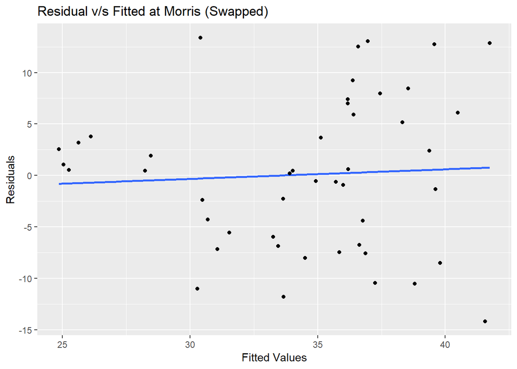

```r
ggplot(yield.rlm1.df[yield.rlm1.df$site=="Morris",],aes(x=.fitted,y=(.resid))) + geom_smooth(method="gam",se=F) +geom_point() + ggtitle("Residual v/s Fitted at Morris (Swapped)") + labs(x="Fitted Values",y="Residuals")
```

#### Point 3

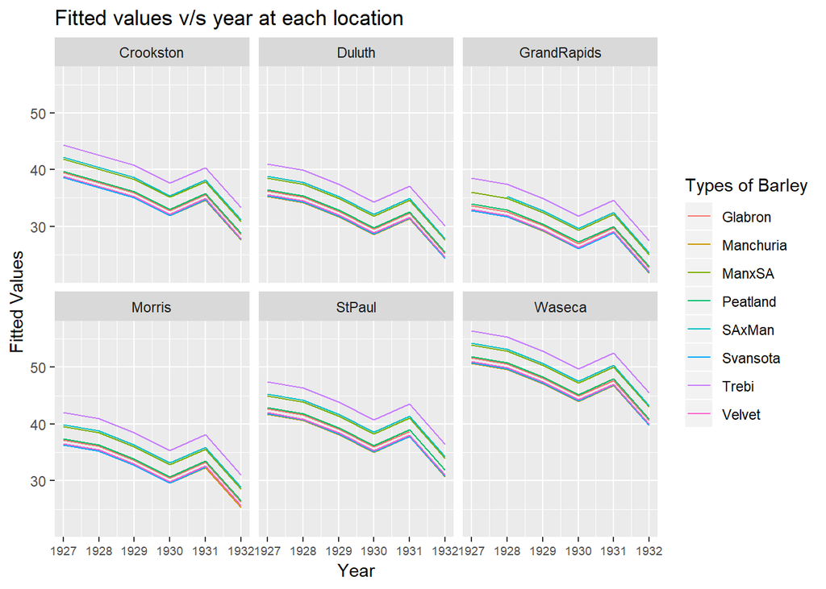

```r
ggplot(yield.rlm.df, aes(x=(year),y=.fitted,colour = factor(gen))) + geom_line() + facet_wrap(~site) +  ggtitle("Fitted values v/s year at each location") + labs(x="Year",y="Fitted Values") +  labs(color='Types of Barley') + theme(axis.text.x =
                   element_text(size  = 7))
```